## Gender, R package maintainers, and the R Foundation

Here’s what I’ve done. First, I looked at the overall counts and ratio of genders of R package maintainers. I found that roughly 15% are women. Second, I had a brief look to see how this has changed over time. I found that the proportion of women maintainers has actually been dropping slightly in recent years. Third, I looked to see how the ratio of genders of R package maintainers, as a proxy for the R user community, is reflected by the R Foundation, as an entity representing users and leading the R Project. I found, as most R users probably know, that the R Foundation is all male, but it should have at least three women on the list to adequetely represent active R developers. I recommend some specific R developers to add to the R Foundation to improve the effectiveness of the Foundation as a group acting in the interests of R Project and its developers and users.

```r
require("tools")
require("gender")
require("genderdata")
require("Hmisc")
require("stringr")
require("ggplot2")
require("scales")
require("dplyr")
require("XML")
require("RCurl")
require("reshape2")
```

```r
# Thanks Dirk: http://stackoverflow.com/a/11561793/1036500
getPackagesWithTitle <- function() {
  contrib.url(getOption("repos")["CRAN"], "source")
  description <- sprintf("%s/web/packages/packages.rds",  getOption("repos")["CRAN"])
  con <- if(substring(description, 1L, 7L) == "file://") {
    file(description, "rb")
  } else {
    url(description, "rb")
  }
  on.exit(close(con))
  db <- readRDS(gzcon(con))
  rownames(db) <- NULL
  return(db)
}
```

```r
## Set default repo
local({r <- getOption("repos");
       r["CRAN"] <- "http://cran.r-project.org"; options(repos=r)})

db <- getPackagesWithTitle()

db_df <- data.frame(db)
maintainer_year_unclean <- data.frame(name = unname(db_df$Maintainer),
                                      year = as.integer(substr(unname(db_df$Published), 1, 4)))
```

```r
clean_up <- function(x){
  # get rid of punctuation
  x1 <- gsub("[[:punct:]]", " ", x)
  # remove leading space before first name
  x2 <- str_trim(x1 , side="left")
  # get first name only
  x3 <- unlist(lapply(x2, first.word))
  # gender function only takes lower case
  x4 <- tolower(x3)
  return(x4)
}
# apply function to data
maintainer_year_clean <- maintainer_year_unclean
maintainer_year_clean$name <- clean_up(maintainer_year_clean$name)

# compute gender of package maintainers (this takes some time!)
cran_genders_with_nas <- gender(maintainer_year_clean$name)
# remove NA (where we can't be sure of the gender because
# we've only got a first initial, or similar)
cran_genders_with_nas <- unlist(lapply(cran_genders_with_nas, function(i) i$gender))
idx <- !is.na(cran_genders_with_nas)
cran_genders <- cran_genders_with_nas[idx]
```

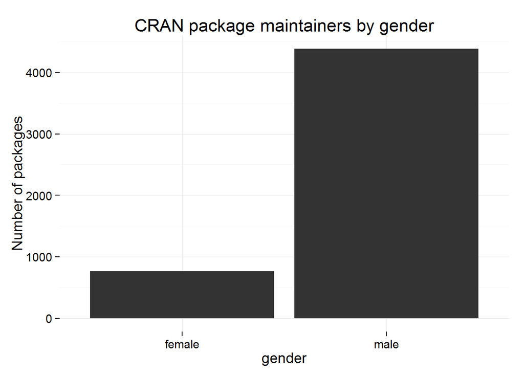

```r
# plots...
# overall counts
counts <- data.frame(female = cran_genders == "female" ,
                    male = cran_genders == "male")
counts_l <- melt(counts + 0)
ggplot(counts_l, aes(variable, value)) +
  geom_bar(stat = "identity") +
  theme_minimal(base_size = 14) +
  ggtitle("CRAN package maintainers by gender") +
  ylab("Number of packages") +
  xlab("gender")
```

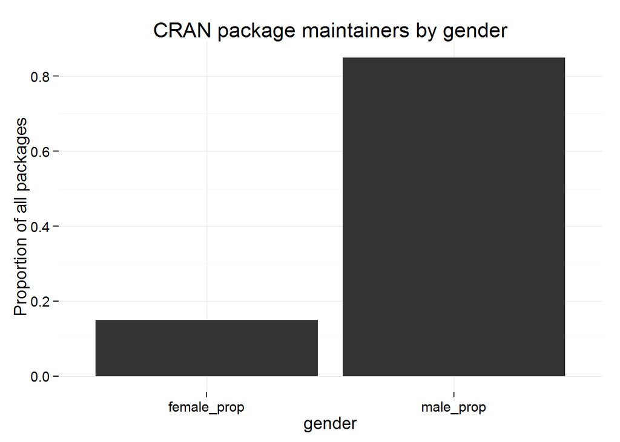

```r
# overall ratio
all <- length(cran_genders)
props <- round(data.frame(female_prop = sum(cran_genders == "female")/all,
                    male_prop = sum(cran_genders == "male")/all), 2)
props_l <- melt(props)
ggplot(props_l, aes(variable, value)) +
  geom_bar(stat = "identity") +
  theme_minimal(base_size = 14) +
  ggtitle("CRAN package maintainers by gender") +
    ylab("Proportion of all packages") +
  xlab("gender")
```

Of all the CRAN packages in this dataset, 15% are maintained by women. This is consistant with the finding of 14% by the “Conversation about R’s Gender Gap: The useR! her Panel” at the 2014 UseR meeting. Now let’s see how that has changed over time.

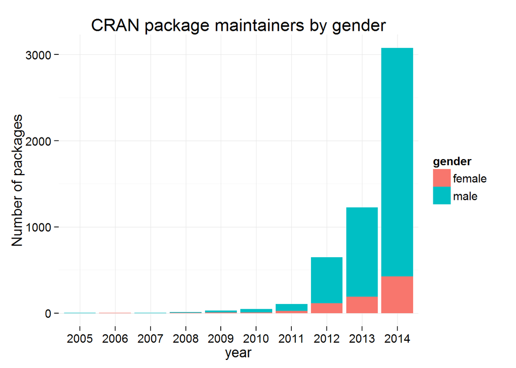

```r
# change over time
# # 'published' date is only most recent version, date
# # of first appearence must come from 'Old sources' archive list
# # have to webscrape on http://cran.r-project.org/src/contrib/Archive/$PACKAGE This has the side-effect of only considering packages
# that have at least one archived version - first version packages
# are excluded. That's tends to favour the inclusion of older packages
# and ones under more active development.

pckg_data <- vector("list", length(nrow(db_df)))
for(i in 1:nrow(db_df)){
  pckge <- db_df$Package[i]
  theurl <- paste0("http://cran.r-project.org/src/contrib/Archive/", db_df$Package[i])
  # print(paste0(i, " ", theurl)) # only for interactive use to know when to come back!
  result <- try(
    tab <- readHTMLTable(theurl),
  ); if(class(result) == "try-error") next;

  # get the date of the earliest archive
  first_date <- strptime(tab[[1]]$`Last modified`[3], "%d-%b-%Y %H:%M")
  pckg_data[[i]] <- data.frame(year = first_date, pckge = pckge)
}

# add year on
the_year  <- as.POSIXlt(strptime(maintainer_year_clean$year, "%Y"))$year + 1900
cran_genders_by_year <- cbind(cran_genders_with_nas, the_year)
# omit NA
cran_genders_by_year <- data.frame(na.omit(cran_genders_by_year))

# plot absolute values
ggplot(cran_genders_by_year, aes(as.factor(the_year), fill = cran_genders_with_nas)) +
  geom_bar(binwidth = 0.5) +
  scale_x_discrete(breaks = unique(cran_genders_by_year$the_year ),
                   labels = unique(cran_genders_by_year$the_year )) +
  theme_minimal(base_size = 14) +
  xlab("year") +
  ggtitle("CRAN package maintainers by gender") +
  ylab("Number of packages") +
  scale_fill_discrete(name = "gender")
```

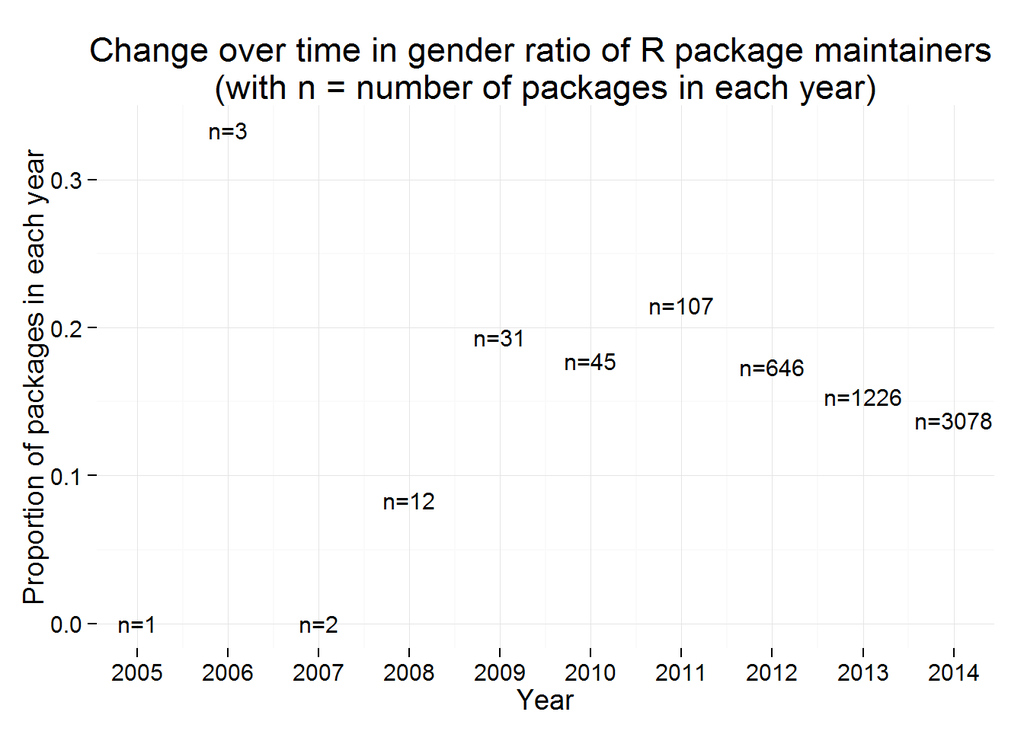

```r
# table of counts and proportions
gender_table <- cran_genders_by_year %>%
  group_by(the_year) %>%
  select(the_year, cran_genders_with_nas) %>%
  summarise(
    count_ml = sum(cran_genders_with_nas == "male"),
    ml = sum(cran_genders_with_nas == "male")/length(cran_genders_with_nas),
    count_fl = sum(cran_genders_with_nas == "female"),
    fl = sum(cran_genders_with_nas == "female")/length(cran_genders_with_nas)
  )

# factor nuisance...
gender_table$the_year <- as.numeric(as.character(gender_table$the_year))

ggplot(gender_table, aes(the_year,  fl)) +
  geom_text(aes(label = paste0("n=", count_ml + count_fl)), size = 4) +
  theme_minimal(base_size = 14) +
  xlab("Year") +
  ylab("Proportion of packages in each year") +
  ggtitle("Change over time in gender ratio of R package maintainers \n(with n = number of packages in each year)") +
  scale_x_continuous(breaks = unique(gender_table$the_year),
                   labels = unique(gender_table$the_year))
```

```r
overall_prop <- round(sum(gender_table$count_fl) / (sum(gender_table$count_ml) + sum(gender_table$count_fl)), 2)

# sanity check for interactive work
x <- identical(
  round(sum(gender_table$count_fl) / (sum(gender_table$count_ml) + sum(gender_table$count_fl)), 2),
# from above
xx <- round(props$female_prop, 2))
```

In more recent years, as the number of packages has increased, the proportion of maintainers that are women has decreased slightly. Could this be a reflection of changing gender ratios amongst the fields that use R, or something else?

In any case, let’s look to see who are the women that have notable achivements on CRAN. Let’s see who were the first, and who has the most packages.

```r
# Who are the pioneering women of R?
maintainter_year_unclean_no_na_female <- maintainer_year_clean[idx & cran_genders_with_nas == 'female', ]
table(maintainter_year_unclean_no_na_female[maintainter_year_unclean_no_na_female$year %in% 2006:2010,])
```

```
##           year
## name       2006 2008 2009 2010
##   chi         0    0    0    1
##   hanna       0    0    1    0
##   ji          0    0    1    0
##   lin         0    0    0    1
##   mee         0    0    0    1
##   na          0    0    0    2
##   pei         0    1    3    1
##   samantha    1    0    0    0
##   sarah       0    0    0    1
##   susanne     0    0    1    0
##   xiao        0    0    0    1
```

A few mis-classified female names here, all of these are actually male: Xiaofeng Wang, Lin Himmelmann, Na (Michael) Li, Chi Yau

Samantha Cook was the first female R package maintainer, and Pei Wang was the most prolific during this period. Let’s look at the top R package maintainers who are women in the whole dataset (2005-2014):

```r
# Who are the top women of R, in terms of maintaining CRAN packages?
maintainter_year_unclean_no_na_female <- maintainer_year_clean[idx & cran_genders_with_nas == 'female', ]

# Make a table that counts the number of packages by each woman, and put the table in order of most to least
maintainter_year_unclean_no_na_female %>%
  group_by(name) %>%
  summarise(number_of_packages = length(year)) %>%
  arrange(desc(number_of_packages)) %>%
  head() %>%
  kable()
```

| name | number_of_packages |
| --- | --- |
| hadley | 33 |
| robin | 30 |
| jan | 20 |
| karline | 16 |
| hana | 14 |
| anne | 10 |

We know that hadley isn’t female, but robin, jean, jan and karline could be male names. So let’s look further.

```r
# inspect ambiguous names
maintainer_year_unclean[maintainer_year_clean$name %in% c('robin', 'jean', 'hadley', 'jan'), ] %>%
  group_by(name) %>%
  summarise(number_of_packages = length(year)) %>%
  arrange(name) %>%
  kable()
```

| name | number_of_packages |
| --- | --- |
| ‘Hadley Wickham’ h.wickham@gmail.com | 6 |
| “Robin K. S. Hankin” hankin.robin@gmail.com | 1 |
| Hadley Wickham h.wickham@gmail.com | 18 |
| Hadley Wickham hadley@rstudio.com | 9 |
| Jan Bulla bulla@math.unicaen.fr | 1 |
| Jan C. Thiele rnetlogo@gmx.de | 1 |
| Jan de Leeuw deleeuw@stat.ucla.edu | 1 |
| Jan Gertheiss jgerthe@uni-goettingen.de | 1 |
| Jan Gorecki j.gorecki@wit.edu.pl | 1 |
| Jan Graffelman jan.graffelman@upc.edu | 3 |
| Jan Grau grau@informatik.uni-halle.de | 1 |
| Jan Klaschka klaschka@cs.cas.cz | 1 |
| Jan Michael Yap jcyap@dcs.upd.edu.ph | 1 |
| Jan Saputra Mueller saputra@cs.tu-berlin.de | 1 |
| Jan Ulbricht jan.ulbricht@stat.uni-muenchen.de | 1 |
| Jan van der Laan djvanderlaan@unrealizedtime.nl | 1 |
| Jan Verbesselt Jan.Verbesselt@wur.nl | 1 |
| Jan Wijffels jwijffels@bnosac.be | 5 |
| Jean-Baptiste Denis Jean-Baptiste.Denis@jouy.inra.fr | 2 |
| Jean-Eudes Dazard jxd101@case.edu | 1 |
| Jean-Francois Plante jfplante@hec.ca | 2 |
| Jean-Pierre Gattuso gattuso@obs-vlfr.fr | 1 |
| Jean-Pierre Rossi jean-pierre.rossi@supagro.inra.fr | 1 |
| Jean Gaudart jean.gaudart@univ-amu.fr | 1 |
| Jean Thioulouse jthioulouse@biomserv.univ-lyon1.fr | 1 |
| Robin Engler robin.engler@gmail.com | 1 |
| Robin Evans evans@stats.ox.ac.uk | 1 |
| Robin Genuer Robin.Genuer@isped.u-bordeaux2.fr | 1 |
| Robin Girard robin.girard@mines-paristech.fr | 2 |
| Robin K. S. Hankin hankin.robin@gmail.com | 21 |
| Robin Lock rlock@stlawu.edu | 2 |
| Robin Nunkesser Robin.Nunkesser@hshl.de | 1 |

With the aid of Google Image search, we can conclude that all the robins, jeans, and jans in the data are male. So let’s remove them from the ‘top women in R’ table, along with a few other ambiguous names.

```r
maintainer_female <- maintainter_year_unclean_no_na_female[!(maintainter_year_unclean_no_na_female$name %in% c('robin', 'jean', 'hadley', 'jan', 'yu', 'gopi')), ]

top_women <- maintainer_female %>%
  group_by(name) %>%
  summarise(number_of_packages = length(year)) %>%
  arrange(desc(number_of_packages))

# get full names
maintainer_year_unclean$first_name <- maintainer_year_clean$name

maintainer_year_unclean %>%
  filter(first_name %in% top_women$name) %>%
  group_by(name) %>%
  summarise(number_of_packages = length(year)) %>%
  arrange(desc(number_of_packages)) %>%
  head() %>%
  kable()
```

| name | number_of_packages |
| --- | --- |
| Karline Soetaert karline.soetaert@nioz.nl | 16 |
| Hana Sevcikova hanas@uw.edu | 13 |
| Ulrike Groemping groemping@beuth-hochschule.de | 6 |
| Anne-Laure Boulesteix boulesteix@ibe.med.uni-muenchen.de | 5 |
| Annie Bouvier Annie.Bouvier@jouy.inra.fr | 5 |
| Daniela Witten dwitten@u.washington.edu | 5 |

Here we see the top R package maintainers who are women. Karline Soetaert and Hana Sevcikova stand out with more than ten packages each. Soetaert is also the author of two major books on using R published by Springer. Two of them are at the University of Washington, where I am. Let’s see how all this compares to the gender balance in the representative organisation for the R Project.

```r
# from https://gist.github.com/hadley/3bdb98c09e602c301d76
members <- c("Bill Venables", "Brian Ripley", "Douglas Bates", "Duncan Murdoch", "Duncan Temple Lang", "Friedrich Leisch", "John Chambers", "John Fox", "Kurt Hornik", "Luke Tierney", "Martin Maechler", "Martyn Plummer", "Paul Murrell", "Peter Dalgaard", "Robert Gentleman", "Roger Bivand", "Ross Ihaka", "Simon Urbanek", "Stefano Iacus", "Thomas Lumley")

core <- c("Douglas Bates", "John Chambers", "Peter Dalgaard", "Seth Falcon", "Robert Gentleman", "Kurt Hornik", "Stefano Iacus", "Ross Ihaka", "Friedrich Leisch", "Uwe Ligges", "Thomas Lumley", "Martin Maechler", "Duncan Murdoch", "Paul Murrell", "Martyn Plummer", "Brian Ripley", "Deepayan Sarkar", "Duncan Temple Lang", "Luke Tierney", "Simon Urbanek")
```

Given that 15% of R package maintainers are women, and that the number of members of the R Foundation is 20, then for an approximate representation of active R developers in the R Foundation, we should expect 3 to be female. Let’s see how that compares to the actual gender ratio of the R Foundation (easy to guess, but let’s work it out to be sure).

```r
members_first_names <- clean_up(members)
members_gender <- gender(members_first_names)
members_gender <- unlist(lapply(members_gender, function(i) i$gender))
prop_female <- sum(members_gender == 'female') / length(members_gender)
```

And the proportion of R Foundation members that are female is 0. Given this underrepresentation, it might be a good idea to vote in Karline Soetaert, Hana Sevcikova and one other active and prominent female R developer as ordinary members of the R Foundation.

While the absolute size of their non-monetary contributions to the R Project might be smaller than many males who are not members of the R Foundation, it is difficult to imagine how an all-male membership can adequentely serve as ‘reference points’ (see the [second goal](http://www.r-project.org/foundation/) of the foundation) for the many women currently learning and using R.